# Analysis and Exploration of Proteomics Data

## Proteomics Data Analysis

Below are shown the steps typically used to transform, process and analyze proteomics data. The analysis steps have been applied over the *EGF-driven protein synthesis* case-study data from [D.A. Rothenberg et al. A Proteomics Approach to Profiling the Temporal Translational Response to Stress and Growth. iScience. 2018; 9:367-381](https://www.sciencedirect.com/science/article/pii/S2589004218301949?via%3Dihub).

We mainly rely [DEP R-package](https://bioconductor.org/packages/release/bioc/html/DEP.html) ([Zhang et.al.](https://www.nature.com/articles/nprot.2017.147)) for integrated analysis workflow for robust and reproducible analysis of mass spectrometry proteomics data for differential protein expression or differential enrichment.

### Loading of R-Packages

We start by loading the R-packages we need to use for our analysis:

```r
library("DEP")
library("readr")
library("vsn")
library("dplyr")
library("tidyr")
library("limma")
library("ggplot2")
library("ggrepel")
library("knitr")
library("tidyverse")
```

### Loading of the data and initial processing

We load the raw protein intensities:

```r
data <- read.delim("../Data/protein_intensities.txt")
colnames(data)
```

```
##  [1] "Gene"         "Accession"    "Sequence"     "PBS_30_Rep1"  "PBS_60_Rep1"
##  [6] "PBS_90_Rep1"  "PBS_120_Rep1" "PBS_150_Rep1" "EGF_30_Rep1"  "EGF_60_Rep1"
## [11] "EGF_90_Rep1"  "EGF_120_Rep1" "EGF_150_Rep1" "PBS_30_Rep2"  "PBS_60_Rep2"
## [16] "PBS_90_Rep2"  "PBS_120_Rep2" "PBS_150_Rep2" "EGF_30_Rep2"  "EGF_60_Rep2"
## [21] "EGF_90_Rep2"  "EGF_120_Rep2" "EGF_150_Rep2" "PBS_30_Rep3"  "PBS_60_Rep3"
## [26] "PBS_90_Rep3"  "PBS_120_Rep3" "PBS_150_Rep3" "EGF_30_Rep3"  "EGF_60_Rep3"
## [31] "EGF_90_Rep3"  "EGF_120_Rep3" "EGF_150_Rep3" "PBS_30_Rep4"  "PBS_60_Rep4"
## [36] "PBS_90_Rep4"  "PBS_120_Rep4" "PBS_150_Rep4" "EGF_30_Rep4"  "EGF_60_Rep4"
## [41] "EGF_90_Rep4"  "EGF_120_Rep4" "EGF_150_Rep4"
```

```r
head(data)
```

```
##     Gene   Accession                      Sequence PBS_30_Rep1 PBS_60_Rep1
## 1  HSPE1  CH10_HUMAN                    GGEIQPVSVK       98880      133900
## 2  HSPE1  CH10_HUMAN                VLQATVVAVGSGSK      215980      282280
## 3 EFTUD2  U5S1_HUMAN                 IAVEPVNPSELPK       20970       37250
## 4  YWHAB 1433B_HUMAN                        SELVQK      157680      215370
## 5  YWHAB 1433B_HUMAN TAFDEAIAELDTLNEESYKDSTLIMQLLR       44780       65620
## 6  YWHAB 1433B_HUMAN                   YLSEVASGDNK       42580       57410
##   PBS_90_Rep1 PBS_120_Rep1 PBS_150_Rep1 EGF_30_Rep1 EGF_60_Rep1 EGF_90_Rep1
## 1       92870       111600       147600      132300      190600      104200
## 2      190020       220860       258580      261080      354470      234470
## 3       22680        27430        33200       29590       45670       32610
## 4      172330       178840       232800      172670      250300      168350
## 5       46350        54980        71120       46100       84290       56390
## 6       44390        50640        56210       44140       75060       50310
##   EGF_120_Rep1 EGF_150_Rep1 PBS_30_Rep2 PBS_60_Rep2 PBS_90_Rep2 PBS_120_Rep2
```

[output cut: 41 more lines]

We then search for duplicated protein identifiers on the data table (Accesion ID), summarize them and then we make unique names using the annotation in the “Accession” column as primary names and the annotation in “Sequence” as to identify for individual quantified peptide sequences.

```r
# Are there any duplicated protein names?
data$Accession %>% duplicated() %>% any()
```

```
## [1] TRUE
```

```r
# Make a table of duplicated protein names
data %>% group_by(Accession) %>% summarize(frequency = n()) %>%
  arrange(desc(frequency)) %>% filter(frequency > 1)
```

```
## # A tibble: 949 × 2
##    Accession   frequency
##    <chr>           <int>
##  1 PLEC_HUMAN        115
##  2 AHNK_HUMAN         86
##  3 FLNA_HUMAN         59
##  4 MYH9_HUMAN         52
##  5 FLNB_HUMAN         44
##  6 TLN1_HUMAN         43
##  7 VINC_HUMAN         34
##  8 MUC16_HUMAN        32
##  9 FAS_HUMAN          31
## 10 KI67_HUMAN         29
## # … with 939 more rows
```

```r
# Make unique names using the annotation in the "Accession" and "Sequence" column.
data_unique <- make_unique(data, "Accession", "Sequence", delim = ";")
head(data_unique)
```

```
##     Gene   Accession                      Sequence PBS_30_Rep1 PBS_60_Rep1
## 1  HSPE1  CH10_HUMAN                    GGEIQPVSVK       98880      133900
## 2  HSPE1  CH10_HUMAN                VLQATVVAVGSGSK      215980      282280
## 3 EFTUD2  U5S1_HUMAN                 IAVEPVNPSELPK       20970       37250
## 4  YWHAB 1433B_HUMAN                        SELVQK      157680      215370
## 5  YWHAB 1433B_HUMAN TAFDEAIAELDTLNEESYKDSTLIMQLLR       44780       65620
## 6  YWHAB 1433B_HUMAN                   YLSEVASGDNK       42580       57410
##   PBS_90_Rep1 PBS_120_Rep1 PBS_150_Rep1 EGF_30_Rep1 EGF_60_Rep1 EGF_90_Rep1
## 1       92870       111600       147600      132300      190600      104200
## 2      190020       220860       258580      261080      354470      234470
## 3       22680        27430        33200       29590       45670       32610
## 4      172330       178840       232800      172670      250300      168350
## 5       46350        54980        71120       46100       84290       56390
## 6       44390        50640        56210       44140       75060       50310
##   EGF_120_Rep1 EGF_150_Rep1 PBS_30_Rep2 PBS_60_Rep2 PBS_90_Rep2 PBS_120_Rep2
```

[output cut: 41 more lines]

```r
# Are there any duplicated names?
data$name %>% duplicated() %>% any()
```

```
## [1] FALSE
```

### Experimental Design

We make an experimental design matrix where we indicate the condition and replicate ID’s for each sample.

```r
# We show the sample ID's
labels <- colnames(data_unique)[4:43]
print(labels)
```

```
##  [1] "PBS_30_Rep1"  "PBS_60_Rep1"  "PBS_90_Rep1"  "PBS_120_Rep1" "PBS_150_Rep1"
##  [6] "EGF_30_Rep1"  "EGF_60_Rep1"  "EGF_90_Rep1"  "EGF_120_Rep1" "EGF_150_Rep1"
## [11] "PBS_30_Rep2"  "PBS_60_Rep2"  "PBS_90_Rep2"  "PBS_120_Rep2" "PBS_150_Rep2"
## [16] "EGF_30_Rep2"  "EGF_60_Rep2"  "EGF_90_Rep2"  "EGF_120_Rep2" "EGF_150_Rep2"
## [21] "PBS_30_Rep3"  "PBS_60_Rep3"  "PBS_90_Rep3"  "PBS_120_Rep3" "PBS_150_Rep3"
## [26] "EGF_30_Rep3"  "EGF_60_Rep3"  "EGF_90_Rep3"  "EGF_120_Rep3" "EGF_150_Rep3"
## [31] "PBS_30_Rep4"  "PBS_60_Rep4"  "PBS_90_Rep4"  "PBS_120_Rep4" "PBS_150_Rep4"
## [36] "EGF_30_Rep4"  "EGF_60_Rep4"  "EGF_90_Rep4"  "EGF_120_Rep4" "EGF_150_Rep4"
```

```r
# We setup the experimental design matrix
experimental_design <- matrix(data = , nrow = length(labels), ncol = 3)
experimental_design[, 1] <- labels
experimental_design[, 2] <- sapply(strsplit(x = labels, split = "_Rep", fixed = TRUE),
                                   "[", 1)
experimental_design[, 3] <- sapply(strsplit(x = labels, split = "_", fixed = TRUE),
                                   "[", 3)
colnames(experimental_design) <- c("label", "condition", "replicate")
experimental_design <- as.data.frame(experimental_design)
print(experimental_design)
```

```
##           label condition replicate
## 1   PBS_30_Rep1    PBS_30      Rep1
## 2   PBS_60_Rep1    PBS_60      Rep1
## 3   PBS_90_Rep1    PBS_90      Rep1
## 4  PBS_120_Rep1   PBS_120      Rep1
## 5  PBS_150_Rep1   PBS_150      Rep1
## 6   EGF_30_Rep1    EGF_30      Rep1
## 7   EGF_60_Rep1    EGF_60      Rep1
## 8   EGF_90_Rep1    EGF_90      Rep1
## 9  EGF_120_Rep1   EGF_120      Rep1
## 10 EGF_150_Rep1   EGF_150      Rep1
## 11  PBS_30_Rep2    PBS_30      Rep2
## 12  PBS_60_Rep2    PBS_60      Rep2
## 13  PBS_90_Rep2    PBS_90      Rep2
## 14 PBS_120_Rep2   PBS_120      Rep2
```

[output cut: 26 more lines]

### Data Processing

#### Summarize Data

We **summarize** the raw data into an object format recognizable by the *DEP* R-package.

```r
# Generate a SummarizedExperiment object using an experimental design
Int_columns <- 4:43 # get Intensity column numbers
data_se <- make_se(data_unique, Int_columns, as.data.frame(experimental_design))
data_se
```

```
## class: SummarizedExperiment
## dim: 5669 40
## metadata(0):
## assays(1): ''
## rownames(5669): CH10_HUMAN CH10_HUMAN.1 ... TRUA_HUMAN RTCB_HUMAN
## rowData names(5): Gene Accession Sequence name ID
## colnames(40): PBS_30_Rep1 PBS_60_Rep1 ... EGF_120_Rep4 EGF_150_Rep4
## colData names(4): label ID condition replicate
```

#### Filtering

We **filter** the proteomics dataset based on missing values. The dataset is filtered for proteins that have a maximum of 2 missing values in at least one condition.

```r
# Filter for proteins that are identified in 2 out of 4 replicates of at least
# one condition
data_filt <- filter_missval(data_se, thr = 2)
data_filt
```

```
## class: SummarizedExperiment
## dim: 2108 40
## metadata(0):
## assays(1): ''
## rownames(2108): 1433B_HUMAN.1 1433E_HUMAN ... ZFR_HUMAN.4 ZN622_HUMAN.2
## rowData names(5): Gene Accession Sequence name ID
## colnames(40): PBS_30_Rep1 PBS_60_Rep1 ... EGF_120_Rep4 EGF_150_Rep4
## colData names(4): label ID condition replicate
```

#### Normalization

We perform a variance stabilizing **transformation/normalization** using the [vsn-package](https://www.bioconductor.org/packages/release/bioc/html/vsn.html). We then also see the differences in the data before and after **normalization**.

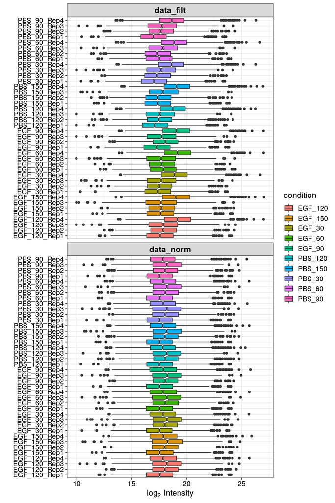

```r
# Normalize the data
data_norm <- normalize_vsn(data_filt)

# Visualize normalization by boxplots for all samples before and after normalization
plot_normalization(data_filt, data_norm)
```

#### Imputation

There are still many missing values in the data. We perform **imputation** in order to impute missing values in the data-set and then visualize the effects which imputation has on the distribution of the data.

```r
# Percentage of missing data
perc <- length(which(is.na(data_norm@assays@data@listData[[1]])))/
  (dim(data_norm@assays@data@listData[[1]])[1]*
     dim(data_norm@assays@data@listData[[1]])[2])
print(paste0(round(x = 100*perc, digits = 2), "%"))
```

```
FALSE [1] "38.21%"
```

```r
# Impute missing data using random draws from a Gaussian distribution centered
# around a minimal value (for MNAR)
data_imp <- impute(data_norm, fun = "MinProb", q = 0.01)
```

[output not shown]

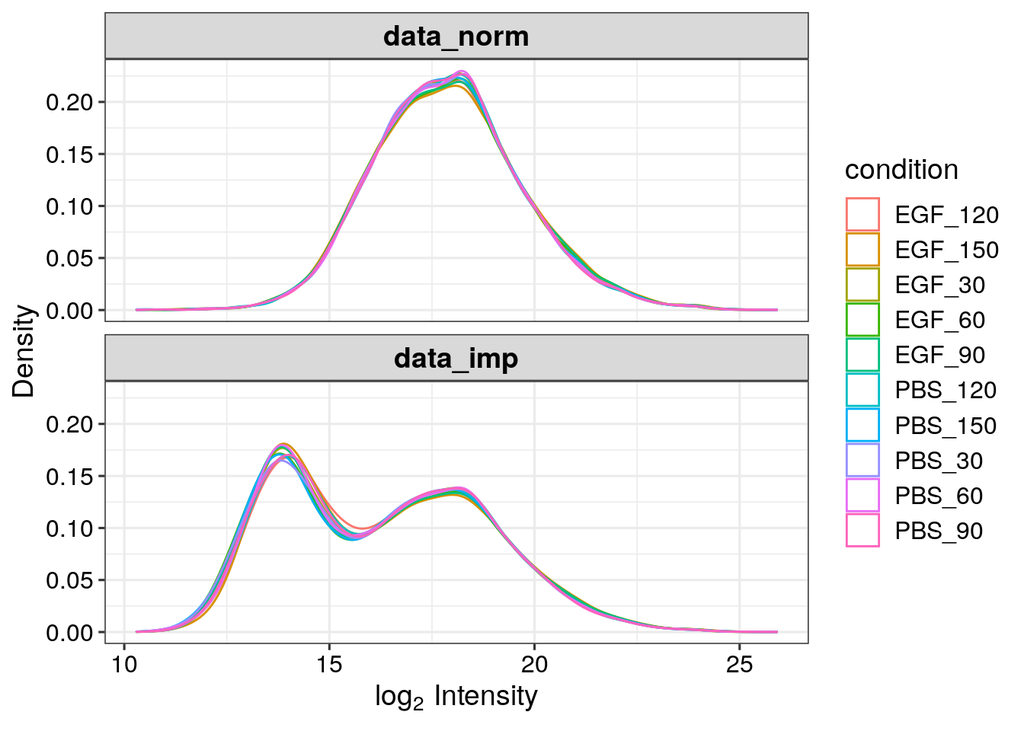

```r
# We can then visualize the effect of imputation on the data
plot_imputation(data_norm, data_imp)
```

#### Interpretation

We perform a **dimensionality reduction/PCA** analysis in order to enhance the interprability of the data by reducing it’s complexity.

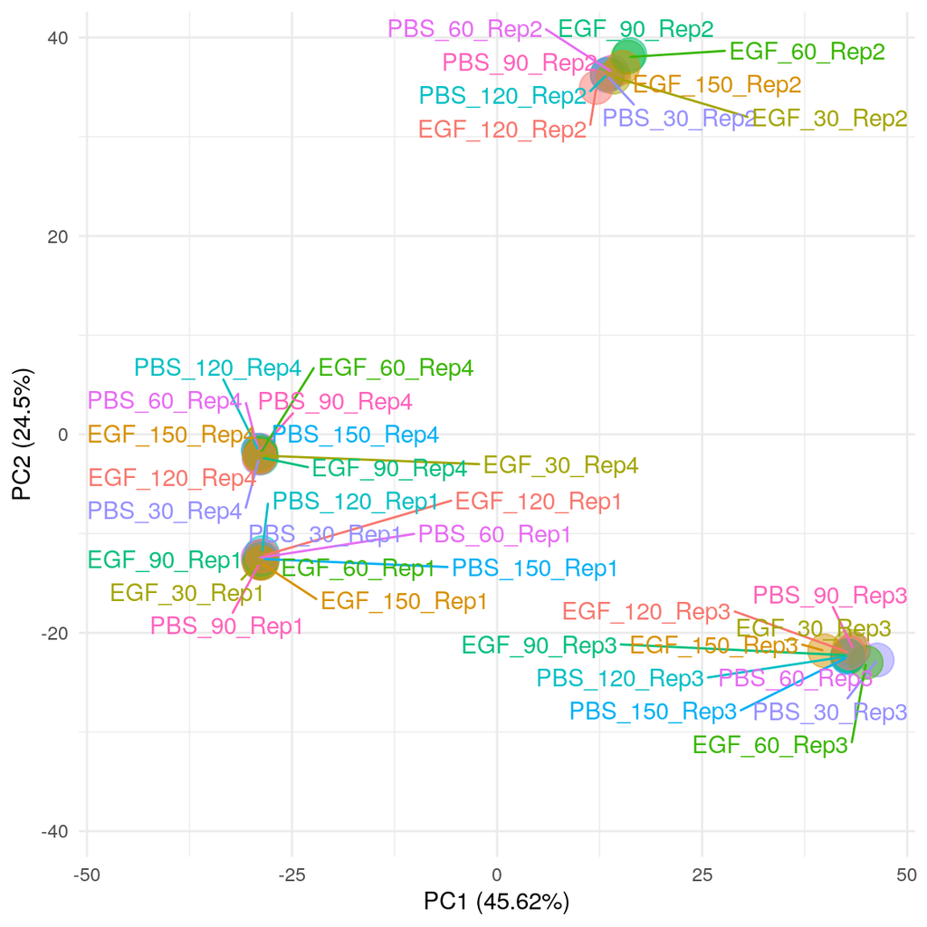

```r
matrix_data <- data_imp@assays@data@listData[[1]]

# PCA plot based on condition
groups <- experimental_design$condition
names(groups) <- experimental_design$label

data.pca <- t(matrix_data)
data.pca <- cbind(data.pca, as.matrix(groups))
colnames(data.pca)[ncol(data.pca)] <- "Group"
data.pca <- as.data.frame(data.pca)
data.pca[, 1:(ncol(data.pca)-1)] <- lapply(data.pca[, 1:(ncol(data.pca)-1)],
                                           function(x) as.numeric(as.character(x)))
res.pca <- prcomp(data.pca[, -ncol(data.pca)], scale. = TRUE)
res.plot <-  as.data.frame(cbind(res.pca$x[, 1], res.pca$x[, 2],
                                 as.character(data.pca$Group), rownames(data.pca)))
res.plot[, 1:2] <- lapply(res.plot[, 1:2], function(x) as.numeric(as.character(x)))
res.plot[, 3:4] <- lapply(res.plot[, 3:4], function(x) as.character(x))
colnames(res.plot) <- c("pc1", "pc2", "Group", "sample")
percentages <- ((res.pca$sdev)^2 / sum(res.pca$sdev^2)*100)[1:2]
pp <- ggplot(res.plot, aes(x=pc1, y=pc2, color=Group)) +
  geom_point(size=7, alpha = 0.5) +
  scale_alpha_discrete(range=c(0.3, 1.0)) +
  theme_minimal() +
  xlab(paste0("PC1 (", round(x = percentages[1], digits = 2), "%)")) +
  ylab(paste0("PC2 (", round(x = percentages[2], digits = 2), "%)")) +
  xlim(c(-max(abs(res.pca$x[, 1])),max(abs(res.pca$x[, 1])))) +
  ylim(c(-max(abs(res.pca$x[, 2])),max(abs(res.pca$x[, 2])))) +
  theme(legend.position = "none") +
  geom_text_repel(data = res.plot, aes(label=sample), max.overlaps = 100)
plot(pp)
```

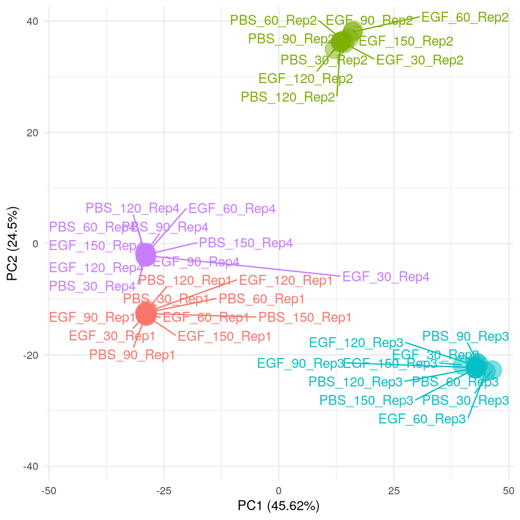

```r
# PCA plot based on relpicate
groups <- experimental_design$replicate
names(groups) <- experimental_design$label

data.pca <- t(matrix_data)
data.pca <- cbind(data.pca, as.matrix(groups))
colnames(data.pca)[ncol(data.pca)] <- "Group"
data.pca <- as.data.frame(data.pca)
data.pca[, 1:(ncol(data.pca)-1)] <- lapply(data.pca[, 1:(ncol(data.pca)-1)],
                                           function(x) as.numeric(as.character(x)))
res.pca <- prcomp(data.pca[, -ncol(data.pca)], scale. = TRUE)
res.plot <-  as.data.frame(cbind(res.pca$x[, 1], res.pca$x[, 2],
                                 as.character(data.pca$Group), rownames(data.pca)))
res.plot[, 1:2] <- lapply(res.plot[, 1:2], function(x) as.numeric(as.character(x)))
res.plot[, 3:4] <- lapply(res.plot[, 3:4], function(x) as.character(x))
colnames(res.plot) <- c("pc1", "pc2", "Group", "sample")
percentages <- ((res.pca$sdev)^2 / sum(res.pca$sdev^2)*100)[1:2]
pp <- ggplot(res.plot, aes(x=pc1, y=pc2, color=Group)) +
  geom_point(size=7, alpha = 0.5) +
  scale_alpha_discrete(range=c(0.3, 1.0)) +
  theme_minimal() +
  xlab(paste0("PC1 (", round(x = percentages[1], digits = 2), "%)")) +
  ylab(paste0("PC2 (", round(x = percentages[2], digits = 2), "%)")) +
  xlim(c(-max(abs(res.pca$x[, 1])),max(abs(res.pca$x[, 1])))) +
  ylim(c(-max(abs(res.pca$x[, 2])),max(abs(res.pca$x[, 2])))) +
  theme(legend.position = "none") +
  geom_text_repel(data = res.plot, aes(label=sample), max.overlaps = 100)
plot(pp)
```

#### Batch Effect Removal

There are **Batch Effects** across replicates which we need to remove. We remove the batch effects through the *removeBatchEffect()* function of the *limma* R-package. Next we verify the removal of batch effects with a **PCA** plot of the transformed data.

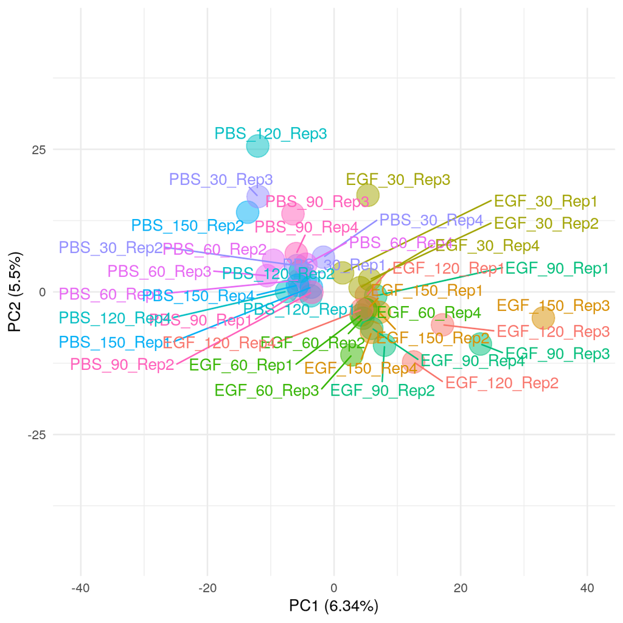

```r
# Remove Batch effects
batch_rem <- removeBatchEffect(x = matrix_data, batch = experimental_design$replicate)

# PCA plot based on condition after removing the batch effects
groups <- experimental_design$condition
names(groups) <- experimental_design$label

data.pca <- t(batch_rem)
data.pca <- cbind(data.pca, as.matrix(groups))
colnames(data.pca)[ncol(data.pca)] <- "Group"
data.pca <- as.data.frame(data.pca)
data.pca[, 1:(ncol(data.pca)-1)] <- lapply(data.pca[, 1:(ncol(data.pca)-1)],
                                           function(x) as.numeric(as.character(x)))
res.pca <- prcomp(data.pca[, -ncol(data.pca)], scale. = TRUE)
res.plot <-  as.data.frame(cbind(res.pca$x[, 1], res.pca$x[, 2],
                                 as.character(data.pca$Group), rownames(data.pca)))
res.plot[, 1:2] <- lapply(res.plot[, 1:2], function(x) as.numeric(as.character(x)))
res.plot[, 3:4] <- lapply(res.plot[, 3:4], function(x) as.character(x))
colnames(res.plot) <- c("pc1", "pc2", "Group", "sample")
percentages <- ((res.pca$sdev)^2 / sum(res.pca$sdev^2)*100)[1:2]
pp <- ggplot(res.plot, aes(x=pc1, y=pc2, color=Group)) +
  geom_point(size=7, alpha = 0.5) +
  scale_alpha_discrete(range=c(0.3, 1.0)) +
  #geom_path(arrow=arrow()) +
  theme_minimal() +
  xlab(paste0("PC1 (", round(x = percentages[1], digits = 2), "%)")) +
  ylab(paste0("PC2 (", round(x = percentages[2], digits = 2), "%)")) +
  xlim(c(-max(abs(res.pca$x[, 1])),max(abs(res.pca$x[, 1])))) +
  ylim(c(-max(abs(res.pca$x[, 2])),max(abs(res.pca$x[, 2])))) +
  theme(legend.position = "none") +
  geom_text_repel(data = res.plot, aes(label=sample), max.overlaps = 100)
plot(pp)
```

> We create the *DEP Object* after removing the batch effects and **comparing the distribution of data** before and after batch effect removal.

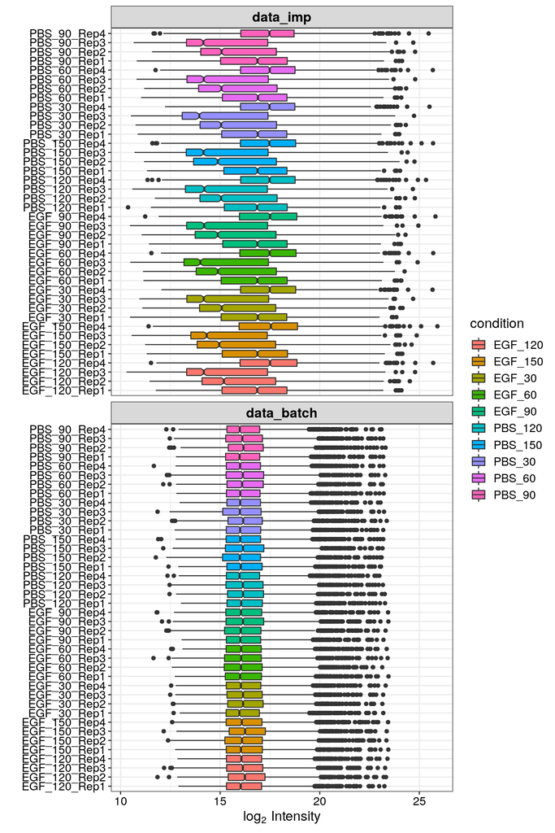

```r
# Create the DEP object after removing the batch effects
data_batch <- data_imp
data_batch@assays@data@listData[[1]] <- batch_rem

# Plot intensity distributions before and after batch correction
plot_normalization(data_imp, data_batch)
```

### Differential Analysis

We perform **Differential Analysis** in order to identify the differentially abundant Proteins.

```r
# Test manually defined comparisons for time-point 60.
data_diff_manual <- test_diff(data_batch, type = "manual",
                              test = c("EGF_60_vs_PBS_60"))

ttop <- as.data.frame(data_diff_manual@elementMetadata)
ttop <- ttop[, c(1:4, 10:12)]
head(ttop)
```

```
FALSE            name  Gene   Accession                      Sequence
FALSE 1 1433B_HUMAN.1 YWHAB 1433B_HUMAN TAFDEAIAELDTLNEESYKDSTLIMQLLR
FALSE 2   1433E_HUMAN YWHAE 1433E_HUMAN                   EAAENSLVAYK
FALSE 3 1433E_HUMAN.1 YWHAE 1433E_HUMAN                 VAGMDVELTVEER
FALSE 4   1433G_HUMAN YWHAG 1433G_HUMAN                     ATVVESSEK
FALSE 5 1433G_HUMAN.1 YWHAG 1433G_HUMAN                NVTELNEPLSNEER
FALSE 6 1433G_HUMAN.2 YWHAG 1433G_HUMAN                    YLAEVATGEK
FALSE   EGF_60_vs_PBS_60_diff EGF_60_vs_PBS_60_p.adj EGF_60_vs_PBS_60_p.val
FALSE 1           -0.27923628              0.9460755              0.5407369
FALSE 2            0.83785487              0.8218940              0.1200808
FALSE 3           -0.68907334              0.8152757              0.1143153
FALSE 4            0.06863029              0.9639692              0.8711915
FALSE 5           -0.04158214              0.9656687              0.9213043
FALSE 6            0.51288591              0.8891282              0.2224957
```

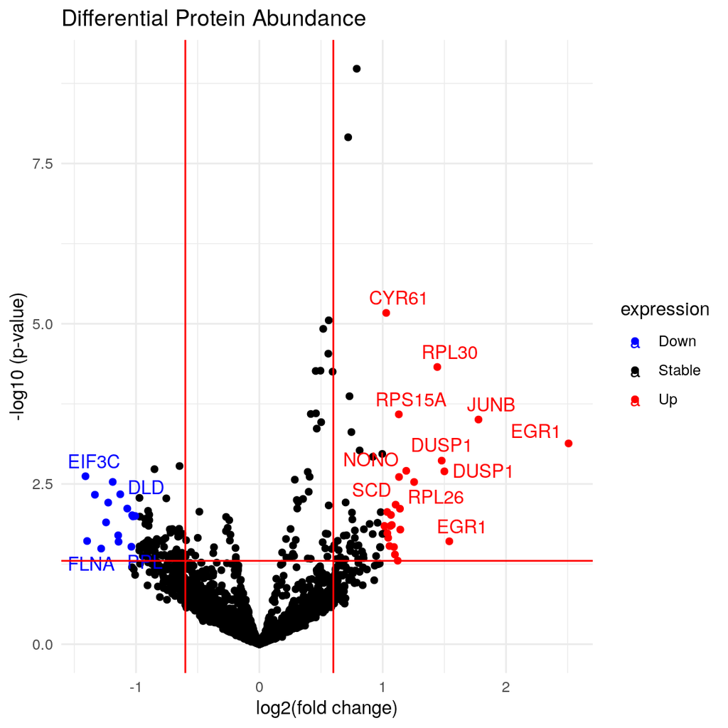

```r
ttop$expression = ifelse(ttop$EGF_60_vs_PBS_60_p.val < 0.05 &
                           abs(ttop$EGF_60_vs_PBS_60_diff) >= 1,
                     ifelse(ttop$EGF_60_vs_PBS_60_diff> 1 ,'Up','Down'),
                     'Stable')

ttop$label <- NA
ttop$label[which(ttop$expression!="Stable")] <-
  ttop$Gene[which(ttop$expression!="Stable")]

p <- ggplot(data=ttop, aes(x=EGF_60_vs_PBS_60_diff,
                           y=-log10(EGF_60_vs_PBS_60_p.val),
                           col=expression, label=label)) +
  geom_point() +
  theme_minimal() +
  geom_text_repel() +
  scale_color_manual(values=c("blue", "black", "red")) +
  geom_vline(xintercept=c(-0.6, 0.6), col="red") +
  geom_hline(yintercept=-log10(0.05), col="red") +
  labs(x="log2(fold change)",
       y="-log10 (p-value)",
       title="Differential Protein Abundance")
p
```